# **Variable importances**

## Modelowanie upliftu

Andżelika Zalewska

Nie jest możliwe policzenie permutational feature importance dla upliftu (przy użyciu standardowych funckji z bibliotek). Jeśli chcemy modelować uplift -> P(puchase|treatment=1) - P(puchase|treatment=0), nasz zbiór danych musiałby mieć dwie kolumny dla Y, jedna byłaby informacją, czy klient kupi produkt, jeśli poddano go treatmentowi, a druga byłaby informacją, czy klient kupi produkt, jeżeli nie poddano go treatmentowi, a mamy tylko jedną z tych informacji. Korzystając z addytywności wartości shapleya -> shap(P(puchase|treatment=1) - P(puchase|treatment=0)) = shap(P(puchase|treatment=1)) - shap(P(puchase|treatment=0)) (co jesteśmy w stanie uzyskać) i dodatkowo z tego, że nasz model jest gradient boosting, to estymacja wartości shapleya będzie szybsza niż modelowanie różnicy dwóch modeli regresyjnych czarnej skrzynki. W załączniku umieszczam dodatkowo kod.

# 1.- 2. Variable importances dla robust Xgboost

```python
shapley_importance_plot(r_xgb_model, X_valid, column_names, treatment_col)
```

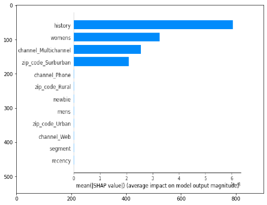

```python
plt.figure(figsize = (9,7))
image = mpimg.imread("robust_xgb_pd5.png")
plt.imshow(image,aspect='auto')
plt.show()
```

Jest to model znaleziony przez lokalne wyszukiwanie hiperparametrów.

Co jednak jest zaskakujące, model ten zależy tylko od 4 zmiennych: od wartości dolarów wydanych przez klienta w minionym roku ("history"), od tego, czy klient kupił jakieś towary damskie („womans”), od tego, czy klient zakupił więcej kanałów w ubiegłym roku ("channel_Multichannel") i od tego, czy kod pocztowy klienta wskazuje na to, że pochodzi on z terenów podmiejskich ("zip_code_Surburban"). Biorąc pod uwagę, że model wykorzystuje drzewa decyzyjne, jest wysoce prawdopodobne, że całkowicie nie używa innych parametrów.

# 3. Variable importances dla kolejno: prostego modelu Xgboost, modelu logistycznego i sieci neuronowej

```python
shapley_importance_plot(xgbmodel, X_valid, column_names, treatment_col)
```

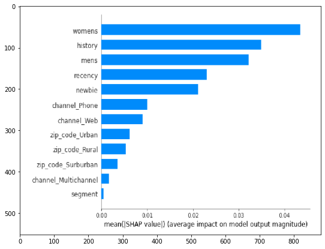

```python
plt.figure(figsize = (9,7))
image = mpimg.imread("simple_xgboost_pd_5.png")
plt.imshow(image,aspect='auto')
plt.show()
```

**Jest to prosty model XGBoost.**

Teraz trzecią najważniejszą zmienną w modelu jest zmienna "mens" identyfikująca, czy klient kupił jakieś towary męskie. Ważną zmienną jest również zmienna "newbie" informująca o byciu nowicjuszem , która raczej nie powinna się tu pojawić ze względu na silną korelację ze zmienną "history" (history > 0 <-> newbie). Ważniejsze od zmiennej "channel_Multichannel" teraz są "channel_Phone" i "channel_Web" (znowu korelacja: "channel_Phone" = 0 i "channel_Web" = 0 <-> "channel_Multichannel" = 1).

```python
shapley_importance_plot(lr_model, X_valid, column_names, treatment_col)
```

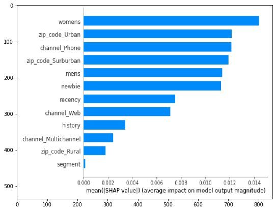

```python
plt.figure(figsize = (9,7))
image = mpimg.imread("logistyczny_pd5.png")
plt.imshow(image,aspect='auto')
plt.show()
```

**Regresja logistyczna**

Variable importances, równe wartościom bezwzględnym parametrów, znacznie różnią się od poprzednich, co dowodzi nieliniowości nawet pierwszego prostego klasyfikatora.

Teraz jednymi z najważniejszych zmiennych są: bez zmian zmienna "womens" informująca o tym, czy klient kupił jakieś towary damskie, zaraz za tą zmienną pojawiają się zmienne, które wcześniej nie były aż tak istotne w modelach: "zip_code_Urban" - czy klient pochodzi z terenów miejskich, "channel_Phone" - czy klient zakupił telefon, "zip_code_Surburban" - czy klient pochodzi z terenów podmiejskich.

```python
shapley_importance_plot(nn_model, X_valid, column_names, treatment_col)
```

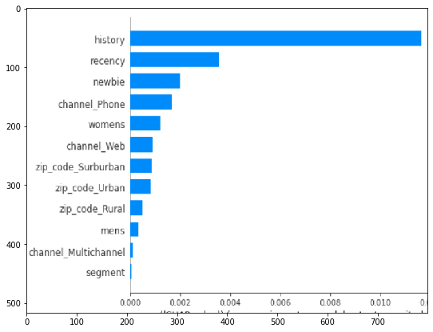

```python
plt.figure(figsize = (9,7))
image = mpimg.imread("siecneuronowa_pd5.png")
plt.imshow(image,aspect='auto')
plt.show()
```

**Jest to overfitted model małej sieci neuronowej.**

Tutaj "history" jest najważniejszą zmienną w modelu, prawdopodobnie dlatego, że pomaga sieci neuronowej w identyfikacji i zapamiętywaniu niektórych przypadków, ponieważ jest jedynym parametrem z tak zmiennymi wartościami.

Kolejną ważną zmienną w modelu jest "recency" - liczba miesięcy od ostatniego zakupu klienta. Zaraz po niej pojawia się zmienna "newbie" - skorelowana z "history" i być może dlatego, dużo mniej istotna.

# **Załącznik**

```python
from profiles import train, X_train, Y_train, X_valid, Y_valid, column_names, treatment_col
from model import train_xgb_model, train_logistic, evaluate_uplift, simple_network, check_acc_diff, check_uplift_diff, local_search_xgb
from explanations import shapley_importance_plot
```

```python
import matplotlib.pyplot as plt
import matplotlib.image as mpimg
```

```python
import shap
from model import predict_treatment
import numpy as np

def shapley_tree(model_predict, obs, dataset, column_names, plot_draw=False):
    explainer = shap.KernelExplainer(model_predict, shap.sample(dataset, 100))
    shap_values = explainer.shap_values(obs)
    if plot_draw:
        shap.waterfall_plot(explainer.expected_value, shap_values, feature_names=column_names)
    return shap_values, explainer.expected_value


def shapley_diff(model, obs, dataset, column_names, treatment_col, plot_draw=True):
    shap_t0, exp0 = shapley_tree(predict_treatment(model, treatment_col, 0), obs, dataset, column_names)
    shap_t1, exp1 = shapley_tree(predict_treatment(model, treatment_col, 1), obs, dataset, column_names)
    if plot_draw:
        shap.waterfall_plot(exp1 - exp0, shap_t1 - shap_t0, feature_names=column_names)
    return shap_t1 - shap_t0, exp1 - exp0


def shapley_importance_plot(model, dataset, column_names, treatment_col, sample_size=100):
    sample = np.random.randint(0, len(dataset), sample_size)
    values, expected = shapley_diff(model, dataset[sample], dataset, column_names, treatment_col, plot_draw=False)
    shap.summary_plot(values, dataset[sample], plot_type="bar", feature_names=column_names)
```

# Modele

Robust XGBoost

```python
r_xgb_model = local_search_xgb(X_train, Y_train, X_valid, Y_valid, treatment_col, just_get_model=True)
```

Prosty XGBoost

```python
xgbmodel = train_xgb_model(X_train, Y_train, X_valid, Y_valid)
```

Model logistyczny

```python
lr_model = train_logistic(X_train, Y_train, X_valid, Y_valid)
```

Sieć neuronowa

```python
nn_model = simple_network(X_train, Y_train, X_valid, Y_valid)
```